# Supervised Learning - Foundations Project: ReCell

## Problem Statement

### Business Context

Buying and selling used phones and tablets used to be something that happened on a handful of online marketplace sites. But the used and refurbished device market has grown considerably over the past decade, and a new IDC (International Data Corporation) forecast predicts that the used phone market would be worth \$52.7bn by 2023 with a compound annual growth rate (CAGR) of 13.6% from 2018 to 2023. This growth can be attributed to an uptick in demand for used phones and tablets that offer considerable savings compared with new models.

Refurbished and used devices continue to provide cost-effective alternatives to both consumers and businesses that are looking to save money when purchasing one. There are plenty of other benefits associated with the used device market. Used and refurbished devices can be sold with warranties and can also be insured with proof of purchase. Third-party vendors/platforms, such as Verizon, Amazon, etc., provide attractive offers to customers for refurbished devices. Maximizing the longevity of devices through second-hand trade also reduces their environmental impact and helps in recycling and reducing waste. The impact of the COVID-19 outbreak may further boost this segment as consumers cut back on discretionary spending and buy phones and tablets only for immediate needs.

### Objective

The rising potential of this comparatively under-the-radar market fuels the need for an ML-based solution to develop a dynamic pricing strategy for used and refurbished devices. ReCell, a startup aiming to tap the potential in this market, has hired you as a data scientist. They want you to analyze the data provided and build a linear regression model to predict the price of a used phone/tablet and identify factors that significantly influence it.

### Data Description

The data contains the different attributes of used/refurbished phones and tablets. The data was collected in the year 2021. The detailed data dictionary is given below.

- brand_name: Name of manufacturing brand
- os: OS on which the device runs
- screen_size: Size of the screen in cm
- 4g: Whether 4G is available or not
- 5g: Whether 5G is available or not
- main_camera_mp: Resolution of the rear camera in megapixels
- selfie_camera_mp: Resolution of the front camera in megapixels
- int_memory: Amount of internal memory (ROM) in GB
- ram: Amount of RAM in GB
- battery: Energy capacity of the device battery in mAh
- weight: Weight of the device in grams
- release_year: Year when the device model was released
- days_used: Number of days the used/refurbished device has been used
- normalized_new_price: Normalized price of a new device of the same model in euros
- normalized_used_price: Normalized price of the used/refurbished device in euros

## Importing necessary libraries

```python
# Installing the libraries with the specified version.
# uncomment and run the following line if Google Colab is being used
# !pip install scikit-learn==1.2.2 seaborn==0.13.1 matplotlib==3.7.1 numpy==1.25.2 pandas==1.5.3 -q --user
```

```python
# Installing the libraries with the specified version.
# uncomment and run the following lines if Jupyter Notebook is being used
# !pip install scikit-learn==1.2.2 seaborn==0.11.1 matplotlib==3.3.4 numpy==1.24.3 pandas==1.5.2 -q --user
```

**Note**: *After running the above cell, kindly restart the notebook kernel and run all cells sequentially from the start again.*

```python
# Mounted at /content/drive for Google Colab to get required data from drive
from google.colab import drive
drive.mount("/content/drive", force_remount=True)
```

```python
# import libraries for data manipulation
import numpy as np
import pandas as pd

# import libraries for data visualization
import matplotlib.pyplot as plt
import seaborn as sns

# import library for probability distribution and statistic data
import scipy.stats as stats

# ignore warnings
import warnings
warnings.filterwarnings("ignore")
```

## Loading the dataset

```python
# read the data from dataset using panda
df = pd.read_csv("/content/drive/MyDrive/ColabNotebooks/used_device_data.csv")
```

## Data Overview

- Observations
- Sanity checks

```python
# After successfull read the data, we can use head() function to view the first 5 rows
df.head()
```

|  | brand_name | os | screen_size | 4g | 5g | main_camera_mp | selfie_camera_mp | int_memory | ram | battery | weight | release_year | days_used | normalized_used_price | normalized_new_price |
| --- | --- | --- | --- | --- | --- | --- | --- | --- | --- | --- | --- | --- | --- | --- | --- |
| 0 | Honor | Android | 14.50 | yes | no | 13.0 | 5.0 | 64.0 | 3.0 | 3020.0 | 146.0 | 2020 | 127 | 4.307572 | 4.715100 |
| 1 | Honor | Android | 17.30 | yes | yes | 13.0 | 16.0 | 128.0 | 8.0 | 4300.0 | 213.0 | 2020 | 325 | 5.162097 | 5.519018 |
| 2 | Honor | Android | 16.69 | yes | yes | 13.0 | 8.0 | 128.0 | 8.0 | 4200.0 | 213.0 | 2020 | 162 | 5.111084 | 5.884631 |
| 3 | Honor | Android | 25.50 | yes | yes | 13.0 | 8.0 | 64.0 | 6.0 | 7250.0 | 480.0 | 2020 | 345 | 5.135387 | 5.630961 |
| 4 | Honor | Android | 15.32 | yes | no | 13.0 | 8.0 | 64.0 | 3.0 | 5000.0 | 185.0 | 2020 | 293 | 4.389995 | 4.947837 |

```python
# we can use tail() funtion to view last 5 rows
df.tail()
```

|  | brand_name | os | screen_size | 4g | 5g | main_camera_mp | selfie_camera_mp | int_memory | ram | battery | weight | release_year | days_used | normalized_used_price | normalized_new_price |
| --- | --- | --- | --- | --- | --- | --- | --- | --- | --- | --- | --- | --- | --- | --- | --- |
| 3449 | Asus | Android | 15.34 | yes | no | NaN | 8.0 | 64.0 | 6.0 | 5000.0 | 190.0 | 2019 | 232 | 4.492337 | 6.483872 |
| 3450 | Asus | Android | 15.24 | yes | no | 13.0 | 8.0 | 128.0 | 8.0 | 4000.0 | 200.0 | 2018 | 541 | 5.037732 | 6.251538 |
| 3451 | Alcatel | Android | 15.80 | yes | no | 13.0 | 5.0 | 32.0 | 3.0 | 4000.0 | 165.0 | 2020 | 201 | 4.357350 | 4.528829 |
| 3452 | Alcatel | Android | 15.80 | yes | no | 13.0 | 5.0 | 32.0 | 2.0 | 4000.0 | 160.0 | 2020 | 149 | 4.349762 | 4.624188 |
| 3453 | Alcatel | Android | 12.83 | yes | no | 13.0 | 5.0 | 16.0 | 2.0 | 4000.0 | 168.0 | 2020 | 176 | 4.132122 | 4.279994 |

Observations:

1. Most of the devices have 4g network
2. Data contains infromation about smartphone and tablets
3. Most of the device have main camera have 13 mp
4. Operating system is Android

```python
df.info()
```

```
<class 'pandas.core.frame.DataFrame'>
RangeIndex: 3454 entries, 0 to 3453
Data columns (total 15 columns):
 #   Column                 Non-Null Count  Dtype
---  ------                 --------------  -----
 0   brand_name             3454 non-null   object
 1   os                     3454 non-null   object
 2   screen_size            3454 non-null   float64
 3   4g                     3454 non-null   object
 4   5g                     3454 non-null   object
 5   main_camera_mp         3275 non-null   float64
 6   selfie_camera_mp       3452 non-null   float64
 7   int_memory             3450 non-null   float64
 8   ram                    3450 non-null   float64
 9   battery                3448 non-null   float64
 10  weight                 3447 non-null   float64
 11  release_year           3454 non-null   int64
 12  days_used              3454 non-null   int64
 13  normalized_used_price  3454 non-null   float64
 14  normalized_new_price   3454 non-null   float64
dtypes: float64(9), int64(2), object(4)
memory usage: 404.9+ KB
```

Observations:

1. Dataset have 3 datatypes. float, int and object.
2. It uses 404.9+ KB memory usage.
3. Total 15 columns and 3454 roes are available in dataset

```python
df.shape
```

```
(3454, 15)
```

Observations:

Dataset has 3454 rows and 15 column.

```python
df.describe().T
```

|  | count | mean | std | min | 25% | 50% | 75% | max |
| --- | --- | --- | --- | --- | --- | --- | --- | --- |
| screen_size | 3454.0 | 13.713115 | 3.805280 | 5.080000 | 12.700000 | 12.830000 | 15.340000 | 30.710000 |
| main_camera_mp | 3275.0 | 9.460208 | 4.815461 | 0.080000 | 5.000000 | 8.000000 | 13.000000 | 48.000000 |
| selfie_camera_mp | 3452.0 | 6.554229 | 6.970372 | 0.000000 | 2.000000 | 5.000000 | 8.000000 | 32.000000 |
| int_memory | 3450.0 | 54.573099 | 84.972371 | 0.010000 | 16.000000 | 32.000000 | 64.000000 | 1024.000000 |
| ram | 3450.0 | 4.036122 | 1.365105 | 0.020000 | 4.000000 | 4.000000 | 4.000000 | 12.000000 |
| battery | 3448.0 | 3133.402697 | 1299.682844 | 500.000000 | 2100.000000 | 3000.000000 | 4000.000000 | 9720.000000 |
| weight | 3447.0 | 182.751871 | 88.413228 | 69.000000 | 142.000000 | 160.000000 | 185.000000 | 855.000000 |
| release_year | 3454.0 | 2015.965258 | 2.298455 | 2013.000000 | 2014.000000 | 2015.500000 | 2018.000000 | 2020.000000 |
| days_used | 3454.0 | 674.869716 | 248.580166 | 91.000000 | 533.500000 | 690.500000 | 868.750000 | 1094.000000 |
| normalized_used_price | 3454.0 | 4.364712 | 0.588914 | 1.536867 | 4.033931 | 4.405133 | 4.755700 | 6.619433 |
| normalized_new_price | 3454.0 | 5.233107 | 0.683637 | 2.901422 | 4.790342 | 5.245892 | 5.673718 | 7.847841 |

Observations:

1. Devices relase year range between 2013 to 2020
2. Main camera mp ranges from 0.08 to 48 and mean 9.46
3. Selfie camera mp ranges from 0.00 to 32 and mean is 6.554
4. Device ram is ranges from 0.02 to 12 and mean is 4.036
5. screen size range from 5.08 to 30.71 and mean is 13.713

## Exploratory Data Analysis (EDA)

- EDA is an important part of any project involving data.
- It is important to investigate and understand the data better before building a model with it.
- A few questions have been mentioned below which will help you approach the analysis in the right manner and generate insights from the data.
- A thorough analysis of the data, in addition to the questions mentioned below, should be done.

**Questions**:

1. What does the distribution of normalized used device prices look like?
2. What percentage of the used device market is dominated by Android devices?
3. The amount of RAM is important for the smooth functioning of a device. How does the amount of RAM vary with the brand?
4. A large battery often increases a device's weight, making it feel uncomfortable in the hands. How does the weight vary for phones and tablets offering large batteries (more than 4500 mAh)?
5. Bigger screens are desirable for entertainment purposes as they offer a better viewing experience. How many phones and tablets are available across different brands with a screen size larger than 6 inches?
6. A lot of devices nowadays offer great selfie cameras, allowing us to capture our favorite moments with loved ones. What is the distribution of devices offering greater than 8MP selfie cameras across brands?
7. Which attributes are highly correlated with the normalized price of a used device?

```python
# function to create box plot
"""
    Boxplot and histogram combined

    data: dataframe
    feature: dataframe column
    figsize: size of figure (default (15,10))
    kde: whether to show the density curve (default False)
    bins: number of bins for histogram (default None)
"""

def draw_boxplot(data, feature, figsize=(15, 10), kde=False, bins=None):

    f2, (ax_box2, ax_hist2) = plt.subplots(
        nrows=2,
        sharex=True,
        gridspec_kw={"height_ratios": (0.25, 0.75)},
        figsize=figsize,
    )
    sns.boxplot(
        data=data, x=feature, ax=ax_box2, showmeans=True, color="violet"
    )
    sns.histplot(
        data=data, x=feature, kde=kde, ax=ax_hist2, bins=bins
    ) if bins else sns.histplot(
        data=data, x=feature, kde=kde, ax=ax_hist2
    )
    ax_hist2.axvline(
        data[feature].mean(), color="green", linestyle="--"
    )
    ax_hist2.axvline(
        data[feature].median(), color="black", linestyle="-"
    )
```

```python
# function to create barplots

"""
Bar plot with percentrange

data - data frame
feature - column name which you want to plot
perc - True or False, wheather to display percentage on bar
n - number of categories to be displayed
"""
def draw_barplot(data, feature, perc =False, n = None):
  total = len(data[feature])
  count = data[feature].nunique()
  if n is None:
    plt.figure(figsize=(count + 2,6))
  else:
    plt.figure(figsize=(n + 2,6))
  plt.xticks(rotation = 90, fontsize = 15)
  ax = sns.countplot(data = data, x = feature, color = 'blue', palette='Paired', order = data[feature].value_counts().index[:n],)
  for p in ax.patches:
    if perc == True:
      label = '{:.1f}%'.format(100 * p.get_height()/total)
    else:
      label = p.get_height()
    x = p.get_x() + p.get_width() / 2
    y = p.get_height()
    ax.annotate(label, (x, y), ha = 'center', va = 'center', size = 12, xytext = (0, 5), textcoords = 'offset points')
  plt.show()
```

## EDA

## (A) Univariate Analysis

## Brand Name

```python
df.brand_name.nunique()
```

```
34
```

```python
df.brand_name.value_counts()
```

| brand_name | count |
| --- | --- |
| Others | 502 |
| Samsung | 341 |
| Huawei | 251 |
| LG | 201 |
| Lenovo | 171 |
| ZTE | 140 |
| Xiaomi | 132 |
| Oppo | 129 |
| Asus | 122 |
| Alcatel | 121 |
| Micromax | 117 |
| Vivo | 117 |
| Honor | 116 |
| HTC | 110 |
| Nokia | 106 |
| Motorola | 106 |
| Sony | 86 |
| Meizu | 62 |
| Gionee | 56 |
| Acer | 51 |
| XOLO | 49 |
| Panasonic | 47 |
| Realme | 41 |
| Apple | 39 |
| Lava | 36 |
| Celkon | 33 |
| Spice | 30 |
| Karbonn | 29 |
| Coolpad | 22 |
| BlackBerry | 22 |
| Microsoft | 22 |
| OnePlus | 22 |
| Google | 15 |
| Infinix | 10 |

**dtype:** int64

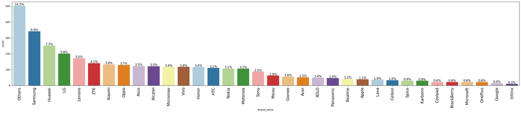

```python
draw_barplot(df, 'brand_name', perc = True)
```

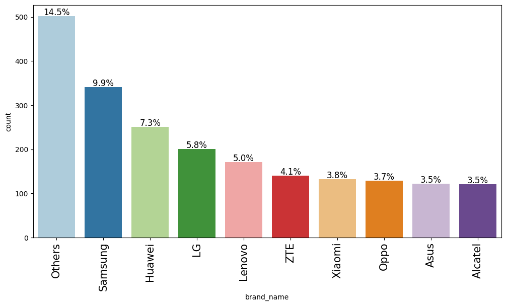

```python
draw_barplot(df, 'brand_name', perc = True, n = 10)
```

Observations:

1. There are 34 different brands of used devices.
2. Samsung devices makes up nearly 10% of total market.
3. Major brands like Apple have smaller market share only making up 1.1% of used devices

## 4G

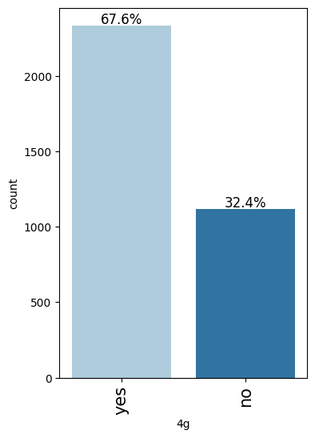

```python
draw_barplot(df, '4g', perc = True)
```

Observations:

1. 4G available on 67.6 % of used devices
2. 4G not available on the remaining 32.4% of userd devices

## 5G

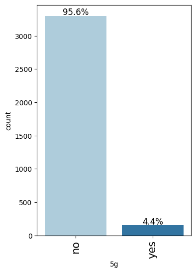

```python
draw_barplot(df, '5g', perc = True)
```

5G is unavailable on 95.6 % of useds devices and only 4.4 % of device have 5G

### Screen Size

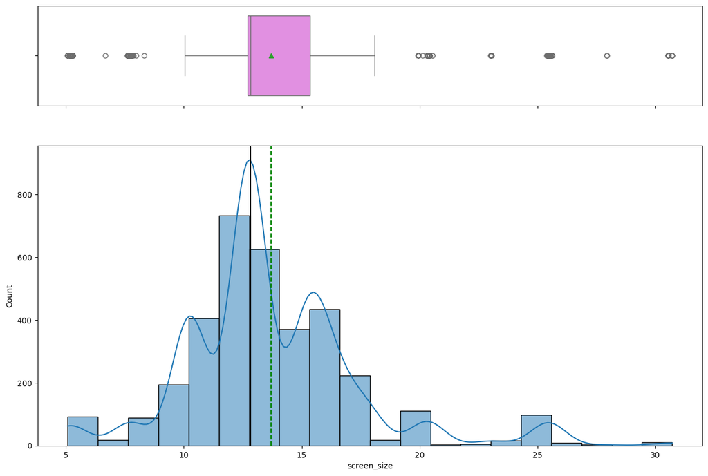

```python
draw_boxplot(df,'screen_size', kde=True,bins=20)
```

Observations:

1. Outlier values exist both left and right to make distribution tail
2. Median screen size is ~13 cm and mean screen is ~14 cm

**(B) Bivariate Analyses**

```python
num_cols = df.select_dtypes(include=np.number).columns.to_list()
num_cols.remove('release_year')
```

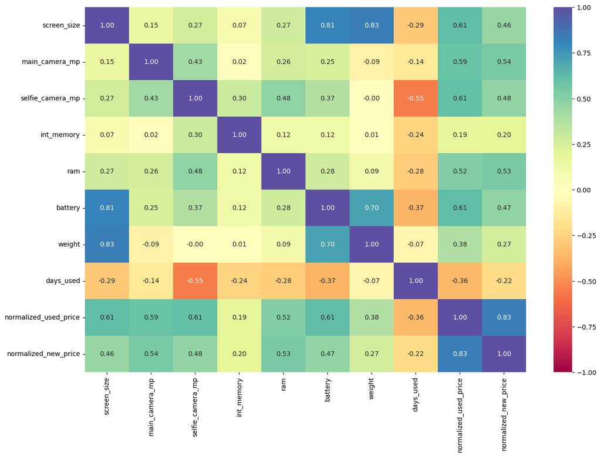

```python
plt.figure(figsize=(15,10))
sns.heatmap(df[num_cols].corr(), annot=True, vmin=-1, vmax=1, fmt=".2f", cmap="Spectral")
plt.show()
```

Observations:

1. Screen_size is highly correlated with battery and weight (R=0.81 and 0.83 respectively)
2. Normalized_used_price also has strong positive correlations with screen_size, selfie_camera_mp and battery (R=0.61)
3. Normalized_used_price is very strongly positively correlated with normalized_new_price (R=0.83)

### 2. What percentage of the used device market is dominated by Android devices?

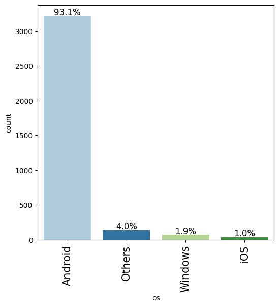

```python
draw_barplot(df, 'os', perc = True)
```

Android devices dominates the used devices with 93.1 % running on Android OS. Apple iOS make up only 1.0 % and other 4%

### 3. The amount of RAM is important for the smooth functioning of a device. How does the amount of RAM vary with the brand?

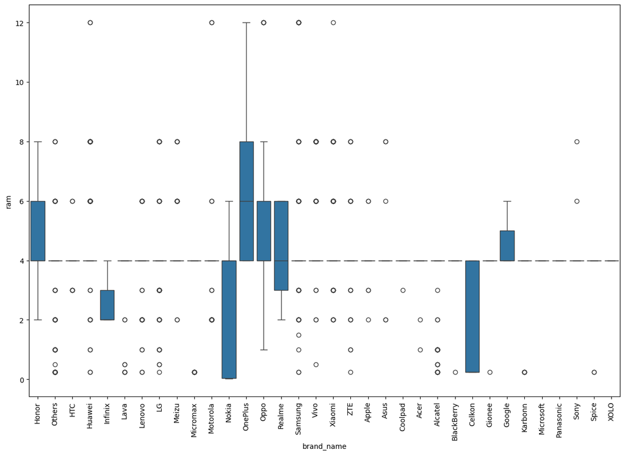

```python
plt.figure(figsize=(15,10))
sns.boxplot(x="brand_name", y="ram", data=df)
plt.xticks(rotation=90)
plt.show()
```

Observations:

1. Brands such as Nokia, Infinix, Celkon seem to more commonly offer RAM sizes lower than 4 GB than most brands.
2. Brands such as Honor, OnePlus, Oppo, Realme and Google seem to more commonly offer RAM sizes greater than 4 GB than most brands
3. Most devices across brands seem to most commonly have 4 GB RAM.
4. There are a number of outlier values both on the lower and upper side of 4 GB for most brands suggesting that most brands ocassionally offer RAM sizes greater or less than 4 GB in certain devices but its not common in most devices

### 4. A large battery often increases a device's weight, making it feel uncomfortable in the hands. How does the weight vary for phones and tablets offering large batteries (more than 4500 mAh)?

```python
df_battery = df[df['battery'] > 4500]
```

```python
df_battery.shape[0]
```

```
341
```

```python
print ("Percentage of device with large battery is", round(df_battery.shape[0]/df.shape[0]*100,2),"%")
```

```
Percentage of device with large battery is 9.87 %
```

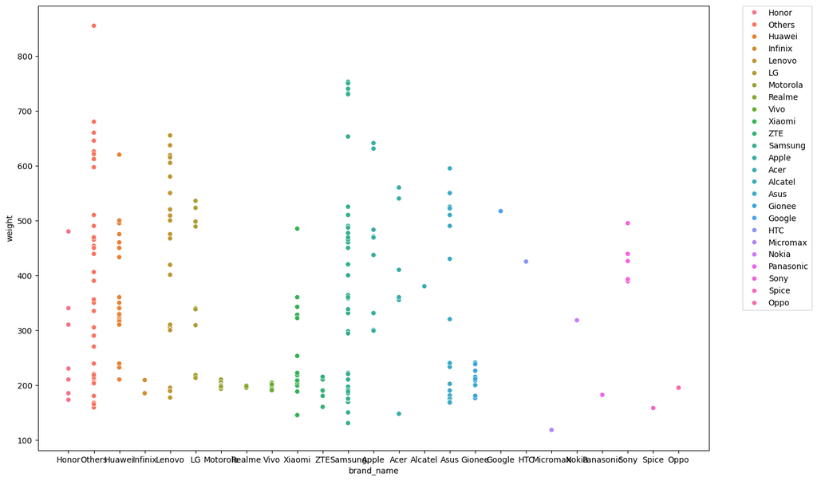

```python
plt.figure(figsize=(15,10))
sns.scatterplot(x="brand_name", y="weight", data=df_battery, hue='brand_name')
plt.legend(bbox_to_anchor=(1.05, 1), loc=2, borderaxespad=0.)
```

Observations:

### 5. Bigger screens are desirable for entertainment purposes as they offer a better viewing experience. How many phones and tablets are available across different brands with a screen size larger than 6 inches?

```python
print("No of devices with greater than 6 inches" , df[df['screen_size'] > 6*2.54].shape[0])
print("Percentage of devices with greater than 6 inches" , round(df[df['screen_size'] > 6*2.54].shape[0]/df.shape[0]*100,2),"%")
```

```
No of devices with greater than 6 inches 1099
Percentage of devices with greater than 6 inches 31.82 %
```

Observations:

1. the data set have 1099 devices have larger than six inches of screen size
2. percentage of devices with more than 6 inches is 31.82%

### 6. A lot of devices nowadays offer great selfie cameras, allowing us to capture our favorite moments with loved ones. What is the distribution of devices offering greater than 8MP selfie cameras across brands?

```python
df_with_8mp = df[df['selfie_camera_mp'] > 8]
```

```python
df_with_8mp.describe().T
```

|  | count | mean | std | min | 25% | 50% | 75% | max |
| --- | --- | --- | --- | --- | --- | --- | --- | --- |
| screen_size | 655.0 | 15.376595 | 1.461576 | 5.280000 | 15.270000 | 15.370000 | 16.280000 | 20.350000 |
| main_camera_mp | 535.0 | 12.138692 | 4.449784 | 0.300000 | 10.500000 | 13.000000 | 13.000000 | 48.000000 |
| selfie_camera_mp | 655.0 | 18.750840 | 6.324722 | 9.000000 | 16.000000 | 16.000000 | 20.000000 | 32.000000 |
| int_memory | 655.0 | 109.874809 | 82.725308 | 8.000000 | 64.000000 | 128.000000 | 128.000000 | 1024.000000 |
| ram | 655.0 | 5.273282 | 1.977736 | 1.000000 | 4.000000 | 4.000000 | 6.000000 | 12.000000 |
| battery | 655.0 | 3885.786260 | 643.128130 | 1470.000000 | 3400.000000 | 4000.000000 | 4200.000000 | 6000.000000 |
| weight | 655.0 | 182.504656 | 22.950825 | 127.000000 | 167.200000 | 181.000000 | 196.500000 | 300.000000 |
| release_year | 655.0 | 2018.619847 | 1.240463 | 2013.000000 | 2018.000000 | 2019.000000 | 2019.000000 | 2020.000000 |
| days_used | 655.0 | 425.967939 | 206.892969 | 91.000000 | 264.500000 | 386.000000 | 557.500000 | 1091.000000 |
| normalized_used_price | 655.0 | 4.963784 | 0.345042 | 3.758406 | 4.734091 | 4.932169 | 5.164982 | 6.619433 |
| normalized_new_price | 655.0 | 5.792289 | 0.556782 | 4.602166 | 5.394399 | 5.703816 | 6.152711 | 7.847841 |

```python
print("No of devices with greater than 8 MP selfie camera" , df_with_8mp['selfie_camera_mp'].shape[0])
print("Percentage of devices with greater than 8 MP selfie camera" , round(df_with_8mp['selfie_camera_mp'].shape[0]/df['selfie_camera_mp'].shape[0]*100,2),"%")
```

```
No of devices with greater than 8 MP selfie camera 655
Percentage of devices with greater than 8 MP selfie camera 18.96 %
```

```python
print("No of brands offerning selfie_camera_mp with greater than 8 MP ", df_with_8mp['brand_name'].nunique())
print("Percentage of brands offerning selfie_camera_mp with greater than 8 MP ", round(df_with_8mp['brand_name'].nunique()/df['brand_name'].nunique()*100,2),"%")
```

```
No of brands offerning selfie_camera_mp with greater than 8 MP  25
Percentage of brands offerning selfie_camera_mp with greater than 8 MP  73.53 %
```

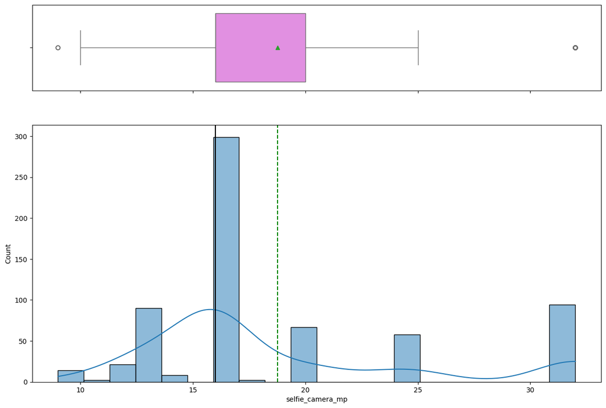

```python
draw_boxplot(df_with_8mp,'selfie_camera_mp', kde=True,bins=20)
```

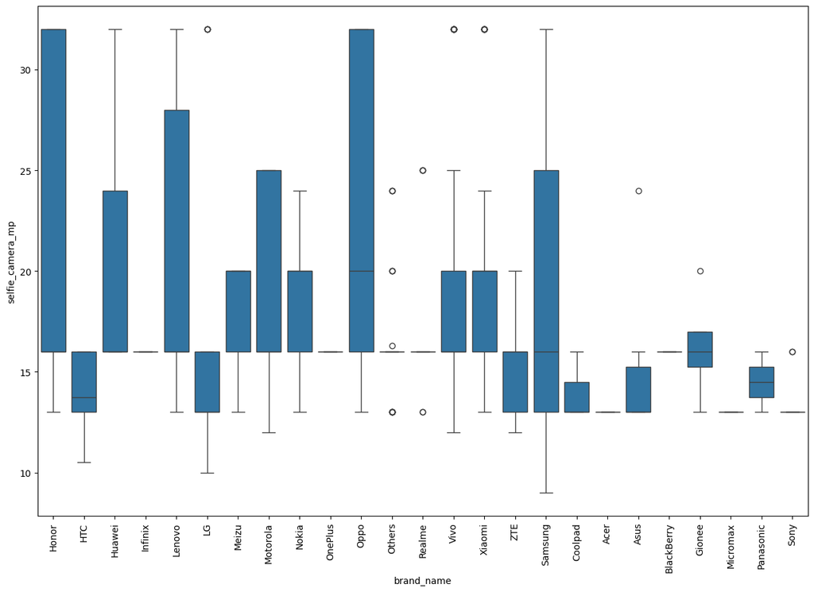

```python
plt.figure(figsize=(15,10))
sns.boxplot(x="brand_name", y="selfie_camera_mp", data=df_with_8mp)
plt.xticks(rotation=90)
plt.show()
```

Observations:

### 7. Which attributes are highly correlated with the normalized price of a used device?

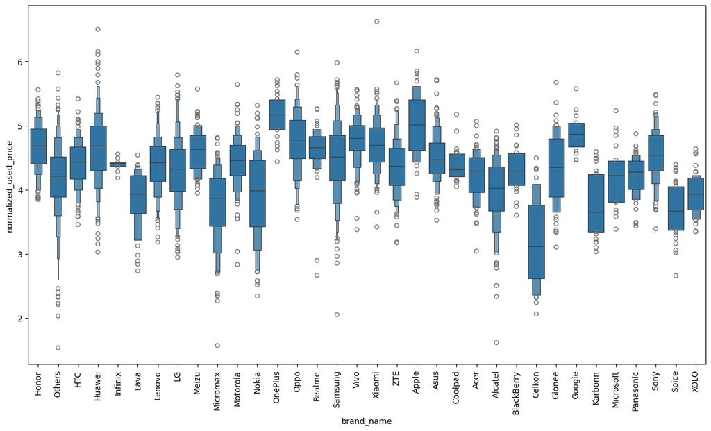

```python
plt.figure(figsize=(15,8))
sns.boxenplot(x="brand_name", y="normalized_used_price", data=df)
plt.xticks(rotation=90)
plt.show()
```

Observations:

1. some brands have higher median used prices such as Apple, Google
2. some brands have lower median used prices sunc as lava, Micromax

## Data Preprocessing

- Missing value treatment
- Feature engineering (if needed)
- Outlier detection and treatment (if needed)
- Preparing data for modeling
- Any other preprocessing steps (if needed)

### Missing value treatment

```python
df.isnull().sum()
```

|  | 0 |
| --- | --- |
| brand_name | 0 |
| os | 0 |
| screen_size | 0 |
| 4g | 0 |
| 5g | 0 |
| main_camera_mp | 179 |
| selfie_camera_mp | 2 |
| int_memory | 4 |
| ram | 4 |
| battery | 6 |
| weight | 7 |
| release_year | 0 |
| days_used | 0 |
| normalized_used_price | 0 |
| normalized_new_price | 0 |

**dtype:** int64

```python
df_final = df.copy()
```

```python
df_final['main_camera_mp']=df_final['main_camera_mp'].fillna(value=df_final['main_camera_mp'].median())

df_final.isnull().sum()
```

|  | 0 |
| --- | --- |
| brand_name | 0 |
| os | 0 |
| screen_size | 0 |
| 4g | 0 |
| 5g | 0 |
| main_camera_mp | 0 |
| selfie_camera_mp | 2 |
| int_memory | 4 |
| ram | 4 |
| battery | 6 |
| weight | 7 |
| release_year | 0 |
| days_used | 0 |
| normalized_used_price | 0 |
| normalized_new_price | 0 |

**dtype:** int64

```python
still_missing = ['main_camera_mp','selfie_camera_mp','battery','weight']


for col in still_missing:
  df_final[col]=df_final[col].fillna(value=df_final.groupby(["brand_name"])[col].transform("median"))

df_final.isnull().sum()
```

|  | 0 |
| --- | --- |
| brand_name | 0 |
| os | 0 |
| screen_size | 0 |
| 4g | 0 |
| 5g | 0 |
| main_camera_mp | 0 |
| selfie_camera_mp | 0 |
| int_memory | 4 |
| ram | 4 |
| battery | 0 |
| weight | 0 |
| release_year | 0 |
| days_used | 0 |
| normalized_used_price | 0 |
| normalized_new_price | 0 |

**dtype:** int64

```python
missing_value_columns = ['main_camera_mp','selfie_camera_mp', 'int_memory','ram', 'battery','weight']


for col in missing_value_columns:
  df_final[col]=df_final[col].fillna(value=df_final.groupby(["brand_name","release_year"])[col].transform("median"))

df_final.isnull().sum()
```

|  | 0 |
| --- | --- |
| brand_name | 0 |
| os | 0 |
| screen_size | 0 |
| 4g | 0 |
| 5g | 0 |
| main_camera_mp | 0 |
| selfie_camera_mp | 0 |
| int_memory | 0 |
| ram | 0 |
| battery | 0 |
| weight | 0 |
| release_year | 0 |
| days_used | 0 |
| normalized_used_price | 0 |
| normalized_new_price | 0 |

**dtype:** int64

Observations:

All missing are treated

### Feature engineering

1. It may make more sense to use the number of years since the release of a device as a numeric predictor variable rather than the absolute value of year of release
2. We will be treating the release_year variable by subtracting it from 2021, the year this data was collected

```python
df_final['years_since_release']=2021-df_final['release_year']
df_final.drop('release_year',axis=1, inplace=True)
df_final.describe().T
```

|  | count | mean | std | min | 25% | 50% | 75% | max |
| --- | --- | --- | --- | --- | --- | --- | --- | --- |
| screen_size | 3454.0 | 13.713115 | 3.805280 | 5.080000 | 12.700000 | 12.830000 | 15.340000 | 30.710000 |
| main_camera_mp | 3454.0 | 9.384534 | 4.700148 | 0.080000 | 5.000000 | 8.000000 | 13.000000 | 48.000000 |
| selfie_camera_mp | 3454.0 | 6.555067 | 6.968440 | 0.000000 | 2.000000 | 5.000000 | 8.000000 | 32.000000 |
| int_memory | 3454.0 | 54.528474 | 84.934991 | 0.010000 | 16.000000 | 32.000000 | 64.000000 | 1024.000000 |
| ram | 3454.0 | 4.032620 | 1.368598 | 0.020000 | 4.000000 | 4.000000 | 4.000000 | 12.000000 |
| battery | 3454.0 | 3132.577446 | 1298.884193 | 500.000000 | 2100.000000 | 3000.000000 | 4000.000000 | 9720.000000 |
| weight | 3454.0 | 182.636856 | 88.360445 | 69.000000 | 142.000000 | 160.000000 | 185.000000 | 855.000000 |
| days_used | 3454.0 | 674.869716 | 248.580166 | 91.000000 | 533.500000 | 690.500000 | 868.750000 | 1094.000000 |
| normalized_used_price | 3454.0 | 4.364712 | 0.588914 | 1.536867 | 4.033931 | 4.405133 | 4.755700 | 6.619433 |
| normalized_new_price | 3454.0 | 5.233107 | 0.683637 | 2.901422 | 4.790342 | 5.245892 | 5.673718 | 7.847841 |
| years_since_release | 3454.0 | 5.034742 | 2.298455 | 1.000000 | 3.000000 | 5.500000 | 7.000000 | 8.000000 |

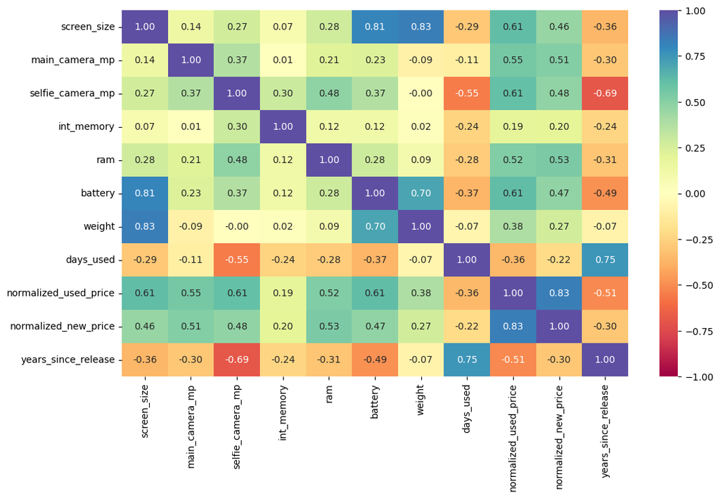

```python
# creating a list of numerical columns
num_cols = df_final.select_dtypes(include=np.number).columns.tolist()

plt.figure(figsize=(12, 7))
sns.heatmap(
    df_final[num_cols].corr(), annot=True, vmin=-1, vmax=1, fmt=".2f", cmap="Spectral"
)
plt.show()
```

Observations:

1. years_since_release is strongly neagtively correlated with selfie_camera_mp (R = - 0.69)
2. years_since_release is highly correlated with days_used (R = 0.75)
3. years_since_release is negatively correlated with normalized_used_price (R = - 0.51)

### Outlier detection

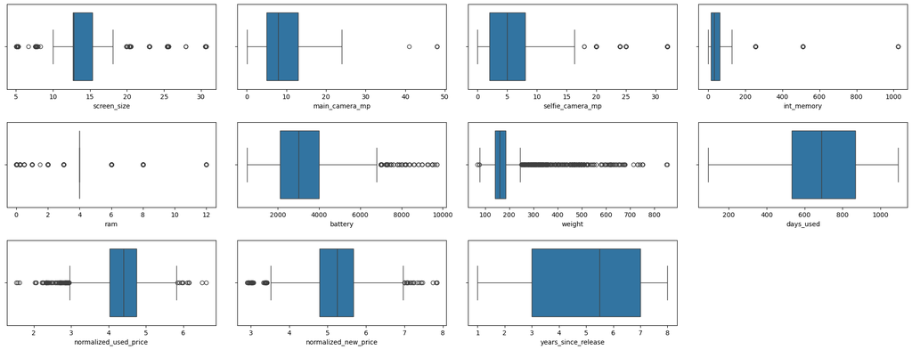

```python
plt.figure(figsize=(20, 10))

for i, variable in enumerate(num_cols):
    plt.subplot(4, 4, i + 1)
    sns.boxplot(data=df_final, x=variable)
    plt.tight_layout(pad=2)

plt.show()
```

Observations:

1.All the outliers seem to represent accurate data and are reasonable values for the variables concerned. 2. Because the outliers represent the natural variability in the dataset.

### Preparing data for modeling

```python
X = df_final.drop(["normalized_used_price"], axis=1)
y = df_final["normalized_used_price"]

print(X.head())
print(y.head())
```

```
  brand_name       os  screen_size   4g   5g  main_camera_mp  \
0      Honor  Android        14.50  yes   no            13.0
1      Honor  Android        17.30  yes  yes            13.0
2      Honor  Android        16.69  yes  yes            13.0
3      Honor  Android        25.50  yes  yes            13.0
4      Honor  Android        15.32  yes   no            13.0

   selfie_camera_mp  int_memory  ram  battery  weight  days_used  \
0               5.0        64.0  3.0   3020.0   146.0        127
1              16.0       128.0  8.0   4300.0   213.0        325
2               8.0       128.0  8.0   4200.0   213.0        162
3               8.0        64.0  6.0   7250.0   480.0        345
4               8.0        64.0  3.0   5000.0   185.0        293

   normalized_new_price  years_since_release
0              4.715100                    1
1              5.519018                    1
2              5.884631                    1
3              5.630961                    1
4              4.947837                    1
0    4.307572
1    5.162097
2    5.111084
3    5.135387
4    4.389995
Name: normalized_used_price, dtype: float64
```

```python
X = pd.get_dummies(
    X,
    columns=X.select_dtypes(include=["object", "category"]).columns.tolist(),
    drop_first=True,
)
X.head()
```

|  | screen_size | main_camera_mp | selfie_camera_mp | int_memory | ram | battery | weight | days_used | normalized_new_price | years_since_release | ... | brand_name_Spice | brand_name_Vivo | brand_name_XOLO | brand_name_Xiaomi | brand_name_ZTE | os_Others | os_Windows | os_iOS | 4g_yes | 5g_yes |
| --- | --- | --- | --- | --- | --- | --- | --- | --- | --- | --- | --- | --- | --- | --- | --- | --- | --- | --- | --- | --- | --- |
| 0 | 14.50 | 13.0 | 5.0 | 64.0 | 3.0 | 3020.0 | 146.0 | 127 | 4.715100 | 1 | ... | False | False | False | False | False | False | False | False | True | False |
| 1 | 17.30 | 13.0 | 16.0 | 128.0 | 8.0 | 4300.0 | 213.0 | 325 | 5.519018 | 1 | ... | False | False | False | False | False | False | False | False | True | True |
| 2 | 16.69 | 13.0 | 8.0 | 128.0 | 8.0 | 4200.0 | 213.0 | 162 | 5.884631 | 1 | ... | False | False | False | False | False | False | False | False | True | True |
| 3 | 25.50 | 13.0 | 8.0 | 64.0 | 6.0 | 7250.0 | 480.0 | 345 | 5.630961 | 1 | ... | False | False | False | False | False | False | False | False | True | True |
| 4 | 15.32 | 13.0 | 8.0 | 64.0 | 3.0 | 5000.0 | 185.0 | 293 | 4.947837 | 1 | ... | False | False | False | False | False | False | False | False | True | False |

5 rows × 48 columns

```python
x_train, x_test, y_train, y_test = train_test_split(X, y, test_size=0.3, random_state=1)
```

```python
print("Number of rows in train data =", x_train.shape[0])
print("Number of rows in test data =", x_test.shape[0])
```

```
Number of rows in train data = 2417
Number of rows in test data = 1037
```

## EDA

- It is a good idea to explore the data once again after manipulating it.

Main camera MP

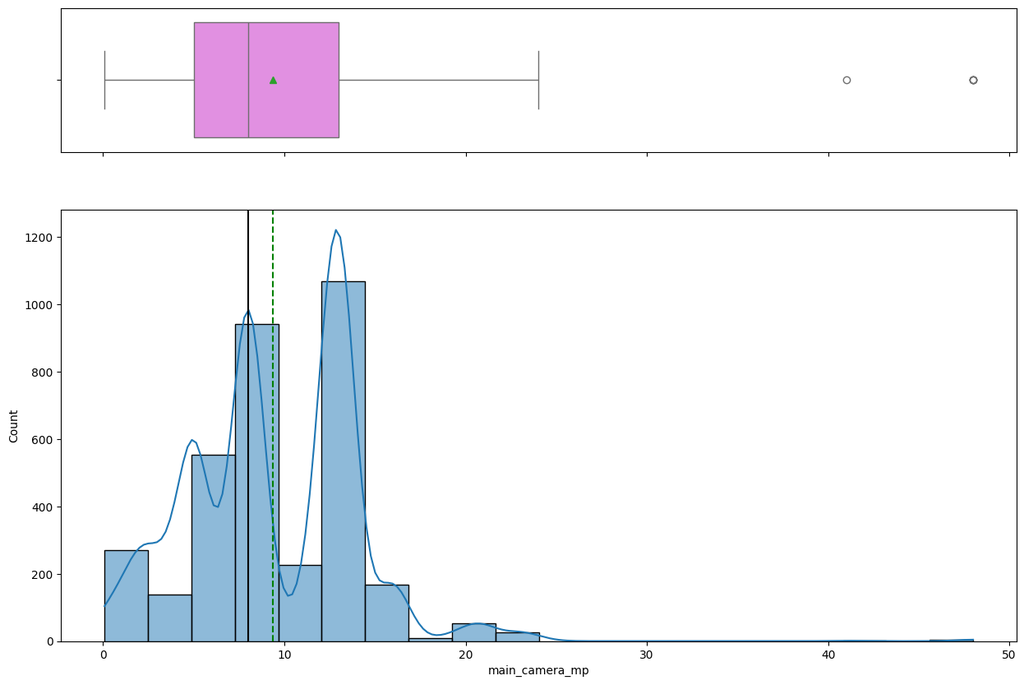

```python
draw_boxplot(df_final,'main_camera_mp', kde=True,bins=20)
```

Selfie Camera MP

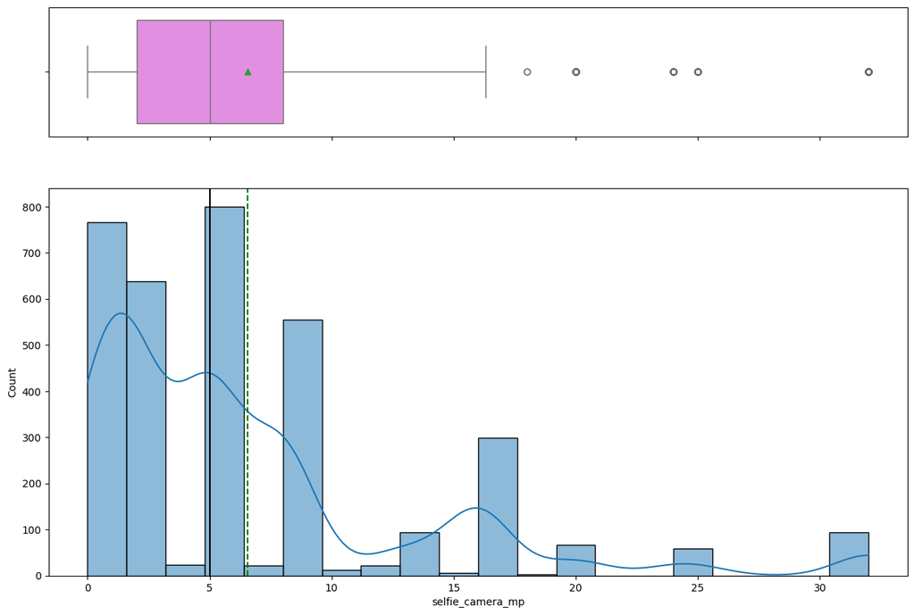

```python
draw_boxplot(df_final,'selfie_camera_mp', kde=True,bins=20)
```

Int Memory

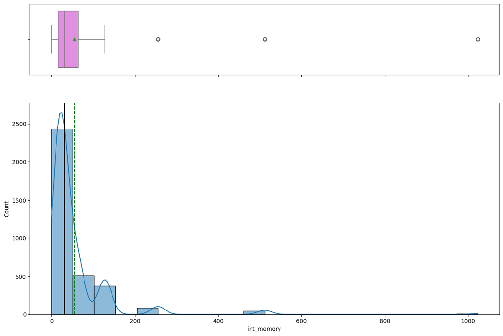

```python
draw_boxplot(df_final,'int_memory', kde=True,bins=20)
```

RAM

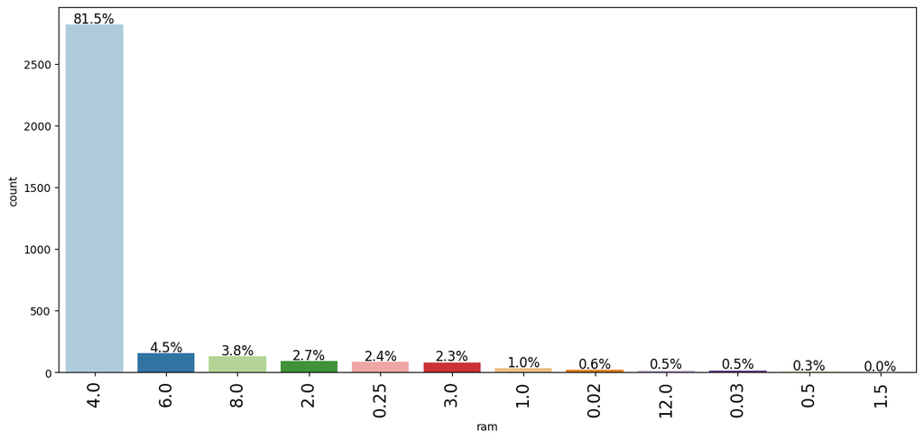

```python
draw_barplot(df_final,"ram", perc=True)
```

Observations:

Broadly the inferences drawn from EDA before data treatment still holds valid and no major change in data distributions for univariate analyses or relationships between different variables are noticed.